# Relational Data Assignment

##### Assignment Instructions

Complete all questions below. After completing the assignment, knit your document, and download both your .Rmd and knitted output. Upload your files for peer review.

For each response, include comments detailing your response and what each line does. Ensure you test your functions with sufficient test cases to identify and correct any potential bugs.

##### Required Libraries

```r
library(tidyverse)
```

##### Question 1.

Identify the primary keys in the following datasets. Be sure to show that you have the primary key by showing there are no duplicate entries.

Lahman::Batting babynames::babynames nasaweather::atmos

```r
# Load necessary libraries
library(dplyr)
library(Lahman)
library(babynames)
library(nasaweather)
# Lahman::Batting
batting <- Lahman::Batting
batting_pk <- batting %>%
  group_by(playerID, yearID, stint) %>%
  summarise(count = n()) %>%
  filter(count > 1)
# babynames::babynames
babynames <- babynames::babynames
babynames_pk <- babynames %>%
  group_by(year, sex, name) %>%
  summarise(count = n()) %>%
  filter(count > 1)
# nasaweather::atmos

atmos <- nasaweather::atmos
atmos_pk <- atmos %>%
  group_by(year, month) %>%
  summarise(count = n()) %>%
  filter(count > 1)
```

##### Question 2.

What is the relationship between the “Batting”, “Master”, and “Salaries” tables in the “Lahman” package? What are the keys for each dataset and how do they relate to each other?

```r
# Lahman::Master
master <- Lahman::People

# Lahman::Salaries
salaries <- Lahman::Salaries

# Check foreign key relationships
batting_people_fk <- batting %>%
  filter(!playerID %in% master$playerID) %>%
  nrow()

batting_salaries_fk <- batting %>%
  filter(!interaction(playerID, yearID) %in% interaction(salaries$playerID, salaries$yearID)) %>%
  nrow()

salaries_people_fk <- salaries %>%
  filter(!playerID %in% master$playerID) %>%
  nrow()

list(
  batting_pk = nrow(batting_pk),
  babynames_pk = nrow(babynames_pk),
  atmos_pk = nrow(atmos_pk),
  batting_people_fk = batting_people_fk,
  batting_salaries_fk = batting_salaries_fk,
  salaries_people_fk = salaries_people_fk
)
```

```
## $batting_pk
## [1] 0
##
## $babynames_pk
## [1] 0
##
## $atmos_pk
## [1] 72
##
## $batting_people_fk
## [1] 0
##
## $batting_salaries_fk
## [1] 84065
##
## $salaries_people_fk
## [1] 0
```

##### Question 3.

Load the “nycflights13” library. Use an appropriate join to add a column containing the airline name to the “flights” dataset present in the library. Be sure to put the carrier code and name in the first two columns of the result so we can see them. Save the result as “flights2”.

```r
# Load necessary libraries
library(dplyr)
library(nycflights13)

# Question 3: Adding Airline Names
flights2 <- flights %>%
  left_join(airlines, by = c("carrier" = "carrier")) %>%
  select(carrier, name, everything())
```

##### Question 4.

Use an appropriate join to add the airport name to the “flights2” dataset you got above. The codes and names of the airports are in the “airports” dataset of the “nycflights13” package. Put the carrier and carrier name first followed by the destination and destination name, then everything else.

```r
airports <- nycflights13::airports

# Join flights2 with airports to add the destination airport name
flights3 <- flights2 %>%
  left_join(airports, by = c("dest" = "faa")) %>%
  rename(name = name.y) %>%
  select(carrier, name, dest, everything())

# Display the first few rows of flights3
head(flights3)
```

```
## # A tibble: 6 × 27
##   carrier name  dest  name.x  year month   day dep_time sched_dep_time dep_delay
##   <chr>   <chr> <chr> <chr>  <int> <int> <int>    <int>          <int>     <dbl>
## 1 UA      Geor… IAH   Unite…  2013     1     1      517            515         2
## 2 UA      Geor… IAH   Unite…  2013     1     1      533            529         4
## 3 AA      Miam… MIA   Ameri…  2013     1     1      542            540         2
## 4 B6      <NA>  BQN   JetBl…  2013     1     1      544            545        -1
## 5 DL      Hart… ATL   Delta…  2013     1     1      554            600        -6
## 6 UA      Chic… ORD   Unite…  2013     1     1      554            558        -4
## # ℹ 17 more variables: arr_time <int>, sched_arr_time <int>, arr_delay <dbl>,
## #   flight <int>, tailnum <chr>, origin <chr>, air_time <dbl>, distance <dbl>,
## #   hour <dbl>, minute <dbl>, time_hour <dttm>, lat <dbl>, lon <dbl>,
## #   alt <dbl>, tz <dbl>, dst <chr>, tzone <chr>
```

##### Question 5.

The “nycflights13” library and the code to create spatial map is provided for you. Now compute the average delay by destination, then join on the airports dataframe so you can show the spatial distribution of delays.

- Use the size or colour of the points to display the average delay for each airport.
- Add the location of the origin and destination (i.e. the lat and lon) to flights.
- Compute the average delay by destination.

Use the textbook for reference.

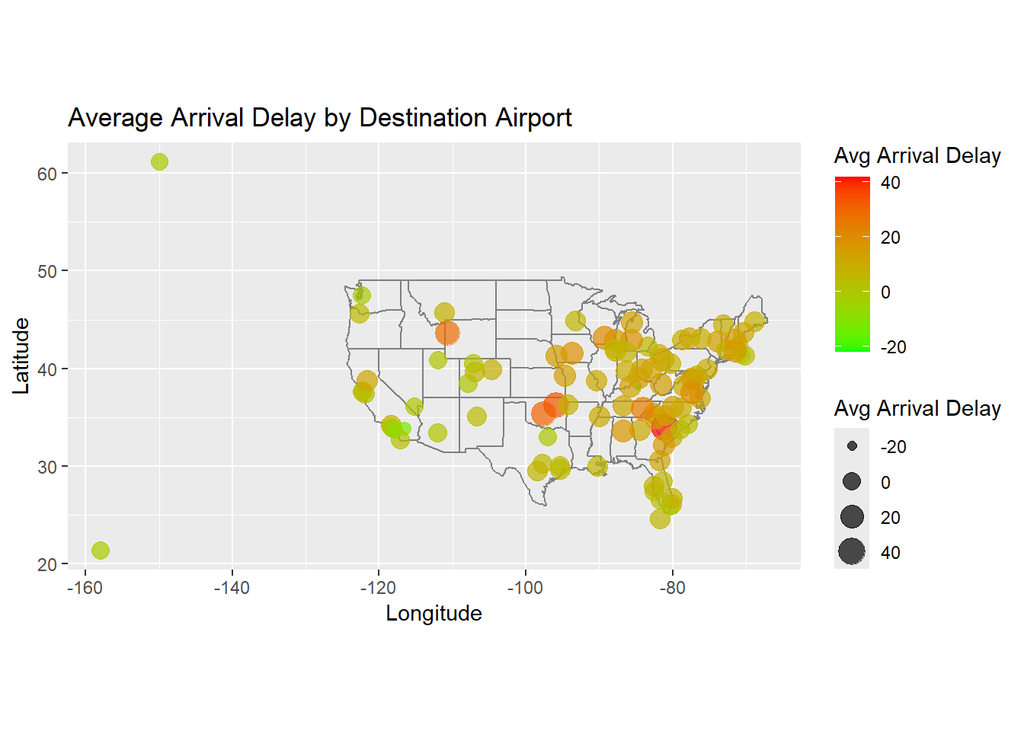

```r
# Load necessary libraries
library(dplyr)
library(nycflights13)
library(ggplot2)
library(maps)
# Step 1: Compute the average delay by destination
avg_delay_by_dest <- flights %>%
  group_by(dest) %>%
  summarise(avg_arr_delay = mean(arr_delay, na.rm = TRUE)) %>%
  ungroup()

# Step 2: Join the average delay data with the airports dataset
avg_delay_airports <- avg_delay_by_dest %>%
  left_join(airports, by = c("dest" = "faa"))

# Step 3: Create a spatial map to visualize the average delays
ggplot(data = avg_delay_airports, aes(x = lon, y = lat)) +
  borders("state") +
  geom_point(aes(size = avg_arr_delay, color = avg_arr_delay), alpha = 0.7) +
  scale_color_gradient(low = "green", high = "red", na.value = "grey50") +
  labs(title = "Average Arrival Delay by Destination Airport",
       x = "Longitude", y = "Latitude",
       size = "Avg Arrival Delay",
       color = "Avg Arrival Delay") +
  coord_quickmap()
```

##### Question 6.

Use a set operation function to find which airport codes from flights are not in the airports dataset.

```r
# Extract unique airport codes from the flights dataset
flights_airports <- flights %>%
  select(dest) %>%
  distinct()

# Extract unique airport codes from the airports dataset
airports_codes <- airports %>%
  select(faa) %>%
  distinct()

# Find airport codes in flights that are not in airports
missing_airports <- setdiff(flights_airports$dest, airports_codes$faa)

# Display the missing airport codes
missing_airports
```

```
## [1] "BQN" "SJU" "STT" "PSE"
```